# Group Task

Nzambuli Daniel, Chesia Anika, Brandon Gem, Waimiri Romeo

2024-02-10

# Loading Libraries to Model SEIR-D with Children and Adults

```r
library(deSolve)
library(tidyverse)
library(DiagrammeR)
```

## States

```r
grViz("digraph flowchart {
      graph [layout = dot,
       rankdir = LR]
      node [fontname = Helvetica, shape = rectangle,]
      tab1 [label = '@@1']
      tab2 [label = '@@2']
      tab3 [label = '@@3']
      tab4 [label = '@@4']
      tab5 [label = '@@5']
      tab6 [label = '@@6']
      tab7 [label = '@@7']
      tab8 [label = '@@8']
      tab9 [label = '@@9']
      # edge definitions with the node IDs
      tab1 -> tab2 [label = 'beta child'];
      tab1 -> tab3 [label = 'beta adult'];
      tab2 -> tab4 [label = 'kapa child'];
      tab4 -> tab6 [label = 'mu child'];
      tab4 -> tab8 [label = 'gamma child'];
      tab3 -> tab5 [label = 'kapa adult'];
      tab5 -> tab7 [label = 'mu adult'];
      tab5 -> tab9 [label = 'gamma adult'];
      }

      [1]: 'Susceptible'
      [2]: 'Exposed Children'
      [3]: 'Exposed Adults'
      [4]: 'Infected Children'
      [5]: 'Infected Adult'
      [6]: 'Dead Children'
      [7]: 'Dead Adults'
      [8]: 'Recovered Children'
      [9]: 'Recovered Adults'
      ")
```

[interactive chart not shown]

The SEIRD model extends the SEIR model by adding a compartment for individuals who have succumbed to the disease. The basic flow of individuals between compartments in the SEIRD model is as follows:

1. S (Susceptible): Individuals who are not infected but can become exposed to the virus.
2. E (Exposed): Individuals who have been exposed to the virus but are not yet infectious.
3. I (Infectious): Individuals who are currently infected and can spread the disease to others.
4. R (Recovered): Individuals who have recovered from the infection and are assumed to be immune.
5. D (Dead): Individuals who have died as a result of the disease.

## The Differential Equations

$$\frac{dS(t)}{dt} = \frac{-\beta S(t)I(t)}{N_{pop}}\\ \\
\frac{dE(t)}{dt} = \frac{+\beta S(t)I(t)}{N_{pop}} - \kappa E(t)\\ \\
\frac{dI(t)}{dt} = -\gamma I(t) + \kappa E(t)\\ \\
\frac{dR(t)}{dt} = +\gamma(1-\mu_h) min(\alpha I(t), I_h) + \gamma(1 -
\mu_n)max(0, \alpha I(t), I_h) + \gamma(1-\alpha) I\\ \\
\frac{dD(t)}{dt} = +\gamma \mu_h min(\alpha I(t), I_h) + \gamma \mu_n
max(0, \alpha I(t), I_h)\\ \\
\frac{dN_{pop}}{dt} = \frac{dS(t)}{dt} + \frac{dE(t)}{dt} +
\frac{dI(t)}{dt} + \frac{dR(t)}{dt} + \frac{dD(t)}{dt} = 0$$

## Initial Set-up

### Population Parameters

```r
population <- 10^6
infectious_no <- 3
N <- 1
epsilon = infectious_no/population
Ih <- 1 ### unlimited hospital capacity
mun <- 0.95 ### 0 < mun < 1
muh <- 1- mun
alpha0 <- 0.6
beta0 <- 1.2
kappa0 <- 1.4 # sigma in normal models
gamma0 <-0.3

unit_time <- 70
```

An assumption is made that:

> - **`mun`**: The proportion of cases that are not hospitalized and die outside of hospitals.
> - **`muh`**: The proportion of cases that are hospitalized and die within hospitals.

> finding the death rate is done by

#### Disease Parameters

```r
# gamma beta and delta
gamma = gamma0
beta = beta0
delta = kappa0
```

### State Parameters

> - **Epsilon** the proportion of infectious individuals
> - **S.child/ S.adult** the ratio of children and adults who are susceptible to the disease.

> $$(1 - \epsilon)\ \rightarrow ratio\ of\ people\ who\ are\ not\ already\
> infected\ by\ the\ disease$$

```r
S.child = 0.3 * (1 - epsilon)
S.adult = 0.7 * (1 - epsilon)
E.child = 0
E.adult = 0
I.child = 0.3 * epsilon
I.adult = 0.7 * epsilon
R.child = 0
R.adult = 0
D.child = 0
D.adult = 0
```

### Transmission Probability

> children have a contact rate of `13`
> - **7** – child to child contact rate
> - **6** – child to adult contact rate

```r
Ro = beta/gamma

c2c.beta = 7/13  * Ro * gamma
c2a.beta = 6/13 * Ro * gamma

# adult
a2a.beta = 10/11 * Ro * gamma
a2c.beta = 1/11 * Ro * gamma
```

### Function to Perform SEIR-D

```r
seir_d <- function(time, state, parameters) {
  S_child <- state[1]
  E_child <- state[2]
  I_child <- state[3]
  R_child <- state[4]
  D_child <- state[5]
  S_adult <- state[6]
  E_adult <- state[7]
  I_adult <- state[8]
  R_adult <- state[9]
  D_adult <- state[10]

  with(as.list(parameters), {
    # number of children and adults
    N_c <- S_child + E_child + I_child + R_child + D_child
    N_a <- S_adult + E_adult + I_adult + R_adult + D_adult

    # beta
    beta_c <- c2c_beta + c2a_beta
    beta_a <- a2c_beta + a2a_beta

    # differential equations
    dS_child <- -beta_c * S_child * I_child / N_c
    dE_child <- beta_c * S_child * I_child / N_c - delta * E_child
    dI_child <- delta * E_child - gamma * I_child - muh * I_child * alpha0
    dR_child <- gamma * I_child
    dD_child <- muh * alpha0 * I_child

    # adult
    dS_adult <- -beta_a * (S_adult * I_adult) / N_a
    dE_adult <- beta_a * (S_adult * I_adult) / N_a - delta * E_adult
    dI_adult <- delta * E_adult - gamma * I_adult - muh * I_adult * alpha0
    dR_adult <- gamma * I_adult
    dD_adult <- muh * alpha0 * I_adult

    return(list(c(dS_child, dE_child, dI_child, dR_child, dD_child, dS_adult, dE_adult, dI_adult, dR_adult, dD_adult)))
  })
}
```

> the new differential equations are

> $$\frac{dE}{dt} = \frac{\beta S I}{N} - \kappa E\\
> \frac{dI}{dt} = \kappa E - (\gamma + \mu) * I\\
> \frac{dR}{dt} = \gamma * I\\
> \frac{dD}{dt} = \mu I$$

### Parameters and States

```r
step_h = 0.1
state <- c(S.child = S.child, E.child = E.child, I.child = I.child, R.child = R.child, D.child = D.child, S.adult = S.adult, E.adult = E.adult, I.adult = I.adult, R.adult = R.adult, D.adult = D.adult)

parameters <- c(beta = beta, kappa = kappa, gamma = gamma, delta = delta, muh = muh, alpha0 = alpha0, c2c_beta = c2c.beta, c2a_beta = c2a.beta, a2a_beta = a2a.beta, a2c_beta = a2c.beta)
times = seq(0, unit_time, step_h)
```

> time is continuous from 0 up to the `unit time`

## Generate the Output

```r
out_seir.d = as.data.frame(ode(y = state, times = times,
                               func = seir_d, parms = parameters))
```

### Output in long format

```r
colnames(out_seir.d)
```

```
##  [1] "time"    "S.child" "E.child" "I.child" "R.child" "D.child" "S.adult"
##  [8] "E.adult" "I.adult" "R.adult" "D.adult"
```

#### Relabel Columns

```r
library(tidyr)
output_long <- out_seir.d %>%  pivot_longer(cols = c(S.child, E.child, I.child, R.child, D.child, S.adult, E.adult, I.adult, R.adult, D.adult),
                        names_to = "state",
                        values_to = "value")
```

### Plot the data

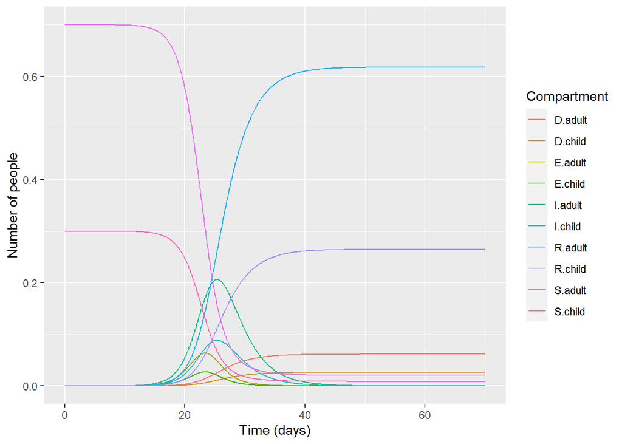

```r
ggplot(data = output_long,
       aes(x = time, y = value, colour = state, group = state)) +
  geom_line() +
  xlab("Time (days)")+
  ylab("Number of people") +
  labs(colour = "Compartment")
```

### Split Plots

```r
child_data = out_seir.d[, c("time","S.child", "E.child", "I.child", "R.child", "D.child")]
adult_data = out_seir.d[, c("time","S.adult", "E.adult", "I.adult", "R.adult", "D.adult")]
```

### Plotting Split data

```r
child_long <- out_seir.d %>%  pivot_longer(cols = c(S.child, E.child, I.child, R.child, D.child),
                        names_to = "state",
                        values_to = "value")
adult_long <- out_seir.d %>%  pivot_longer(cols = c(S.adult, E.adult, I.adult, R.adult, D.adult),
                        names_to = "state",
                        values_to = "value")
```

#### Child plot

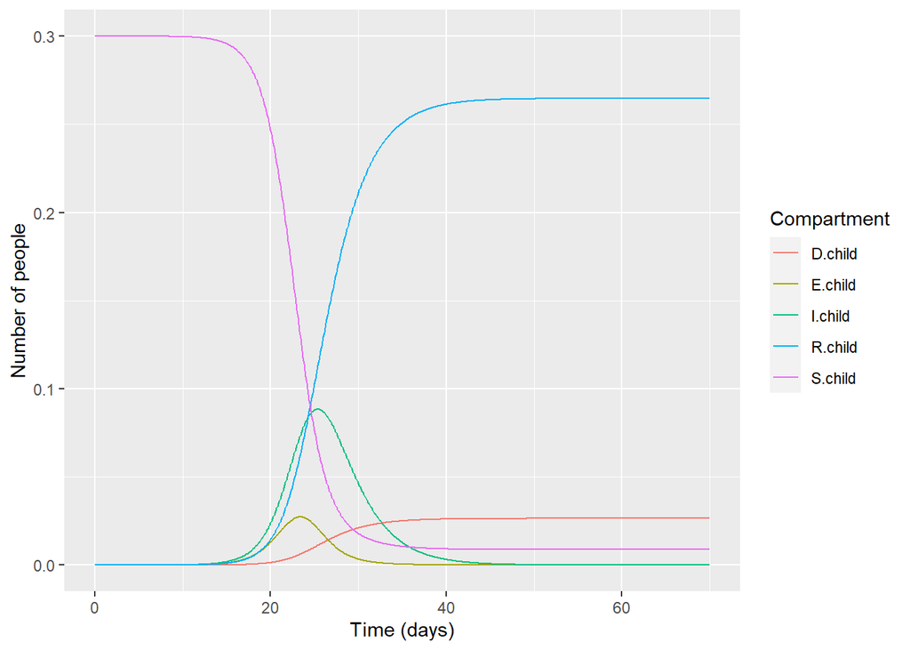

```r
ggplot(data = child_long,
       aes(x = time, y = value, colour = state, group = state)) +
  geom_line() +
  xlab("Time (days)")+
  ylab("Number of people") +
  labs(colour = "Compartment")
```

#### Adult Long

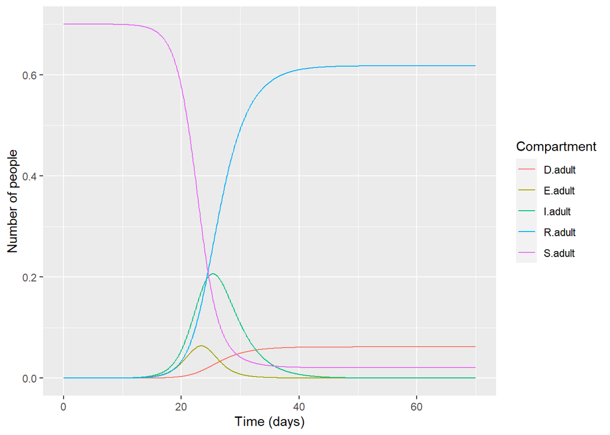

```r
ggplot(data = adult_long,
       aes(x = time, y = value, colour = state, group = state)) +
  geom_line() +
  xlab("Time (days)")+
  ylab("Number of people") +
  labs(colour = "Compartment")
```

### Summary of the Model

```r
summary(out_seir.d)
```

```
##       time         S.child            E.child             I.child
##  Min.   : 0.0   Min.   :0.008793   Min.   :0.000e+00   Min.   :6.000e-07
##  1st Qu.:17.5   1st Qu.:0.008804   1st Qu.:1.397e-06   1st Qu.:1.562e-05
##  Median :35.0   Median :0.010549   Median :3.705e-05   Median :4.128e-04
##  Mean   :35.0   Mean   :0.103977   Mean   :2.967e-03   Mean   :1.259e-02
##  3rd Qu.:52.5   3rd Qu.:0.284045   3rd Qu.:1.192e-03   3rd Qu.:1.023e-02
##  Max.   :70.0   Max.   :0.299999   Max.   :2.737e-02   Max.   :8.849e-02
##     R.child            D.child             S.adult           E.adult
##  Min.   :0.000000   Min.   :0.0000000   Min.   :0.02052   Min.   :0.000e+00
##  1st Qu.:0.004098   1st Qu.:0.0004098   1st Qu.:0.02054   1st Qu.:3.260e-06
##  Median :0.251078   Median :0.0251078   Median :0.02462   Median :8.645e-05
##  Mean   :0.164062   Mean   :0.0164062   Mean   :0.24261   Mean   :6.924e-03
##  3rd Qu.:0.264640   3rd Qu.:0.0264640   3rd Qu.:0.66277   3rd Qu.:2.782e-03
##  Max.   :0.264733   Max.   :0.0264733   Max.   :0.70000   Max.   :6.385e-02
##     I.adult             R.adult            D.adult
##  Min.   :1.400e-06   Min.   :0.000000   Min.   :0.0000000
##  1st Qu.:3.645e-05   1st Qu.:0.009563   1st Qu.:0.0009563
##  Median :9.632e-04   Median :0.585849   Median :0.0585849
##  Mean   :2.937e-02   Mean   :0.382810   Mean   :0.0382810
##  3rd Qu.:2.388e-02   3rd Qu.:0.617493   3rd Qu.:0.0617493
##  Max.   :2.065e-01   Max.   :0.617710   Max.   :0.0617709
```